# Chapter 13 Correspondence Analysis

## Introduction

**Correspondence Analysis (CA)** is an exploratory multivariate technique used to analyze and visualize relationships in **categorical data**, typically organized in a **contingency table** (e.g., rows = groups, columns = categories, entries = counts).

It plays a role similar to **Principal Component Analysis (PCA)** but for **frequency / count data** rather than continuous variables.  
The goal is to represent both **rows** and **columns** as points in a **low-dimensional space** (usually 2D), where distances reflect patterns of association:

- Row points that are close together have **similar response profiles**.
- Column points that are close together tend to be **chosen/observed with similar rows**.
- Proximity between a row point and a column point indicates **strong association**.

CA is widely used in marketing, survey analysis, social sciences, and ecology.

## Basic Setup and Notation

Suppose we have an $I \times J$ contingency table of counts: $$ F = [f_{ij}], \quad i = 1,\dots,I,\; j = 1,\dots,J, $$ with total $$ N = \sum_{i=1}^I \sum_{j=1}^J f_{ij}. $$

Define the **relative frequency matrix**: $$ P = \frac{1}{N} F = [p_{ij}]. $$

Row and column marginal proportions: $$ r_i = \sum_j p_{ij}, \quad c_j = \sum_i p_{ij}, $$ and let $D_r$ and $D_c$ be diagonal matrices with $r_i$ and $c_j$ on the diagonals.

If rows and columns were **independent**, we’d expect $$ p_{ij}^{(\text{indep})} = r_i c_j. $$

CA studies the deviations from independence: $$ P - r c^T. $$

These deviations are standardized and decomposed using **singular value decomposition (SVD)**: $$ S = D_r^{-1/2}(P - r c^T)D_c^{-1/2}, $$ $$ S = U \Lambda V^T. $$

The low-dimensional **principal coordinates** (to plot) are:

- Row points: $$ F_r = D_r^{-1/2} U \Lambda, $$
- Column points: $$ F_c = D_c^{-1/2} V \Lambda. $$

Plotting the first one or two dimensions from these coordinates gives the **correspondence map**.

### 🎓 Class Exercise: Movie Preferences by Age Group

To explore how **Correspondence Analysis (CA)** can be used to visualize associations between **categorical variables** : *age group* and *movie genre preferences*.

**Background:**  
The dataset represents counts of people from different age groups who selected each movie genre as their favorite.  
CA will help us determine which genres are most associated with which age groups by projecting both onto a common two-dimensional map.

Identify the most popular genre for the youngest group (18–25) and the most popular genre for the oldest group (61+).

```r
# install.packages("ca")
# install.packages("tidyverse")

library(ca)
library(tidyverse)

movie.mat = matrix(
  c(30, 50, 20, 40, 10,
    25, 35, 30, 20, 15,
    10, 15, 40, 10, 25,
     5, 10, 25,  5, 30),
  nrow = 4, byrow = TRUE
)

rownames(movie.mat) = c("18–25", "26–40", "41–60", "61+")
colnames(movie.mat) = c("Action", "Comedy", "Drama", "Sci-Fi", "Romance")

movie.mat
```

A matrix: 4 × 5 of type dbl

|  | Action | Comedy | Drama | Sci-Fi | Romance |
| --- | --- | --- | --- | --- | --- |
| 18–25 | 30 | 50 | 20 | 40 | 10 |
| 26–40 | 25 | 35 | 30 | 20 | 15 |
| 41–60 | 10 | 15 | 40 | 10 | 25 |
| 61+ | 5 | 10 | 25 | 5 | 30 |

```r
# Run Correspondence Analysis
ca.fit = ca(movie.mat)

# Basic summary of results (inertia, dimension contributions, etc.)
summary(ca.fit)
```

```
Principal inertias (eigenvalues):

 dim    value      %   cum%   scree plot
 1      0.192674  92.5  92.5  ***********************
 2      0.012301   5.9  98.4  *
 3      0.003414   1.6 100.0
        -------- -----
 Total: 0.208389 100.0


Rows:
    name   mass  qlt  inr    k=1 cor ctr    k=2 cor ctr
1 | 1825 |  333  994  373 | -476 973 392 |  -69  20 128 |
2 | 2640 |  278  830   50 | -156 640  35 |   85 190 162 |
3 | 4160 |  222  978  207 |  416 893 200 |  128  85 297 |
4 |   61 |  167  998  370 |  657 932 373 | -175  66 413 |

Columns:
    name   mass  qlt  inr    k=1 cor ctr    k=2 cor ctr
1 | Actn |  156  946   99 | -349 919  98 |   60  27  45 |
2 | Cmdy |  244  992  138 | -341 987 147 |  -24   5  12 |
3 | Dram |  256  994  201 |  374 854 185 |  151 140 475 |
4 | SciF |  167  953  173 | -447 925 173 |  -78  28  82 |
5 | Rmnc |  178  999  390 |  655 940 396 | -163  58 386 |
```

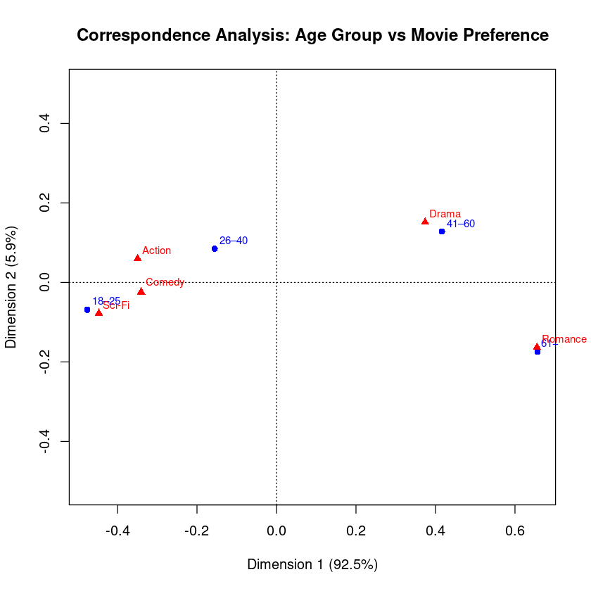

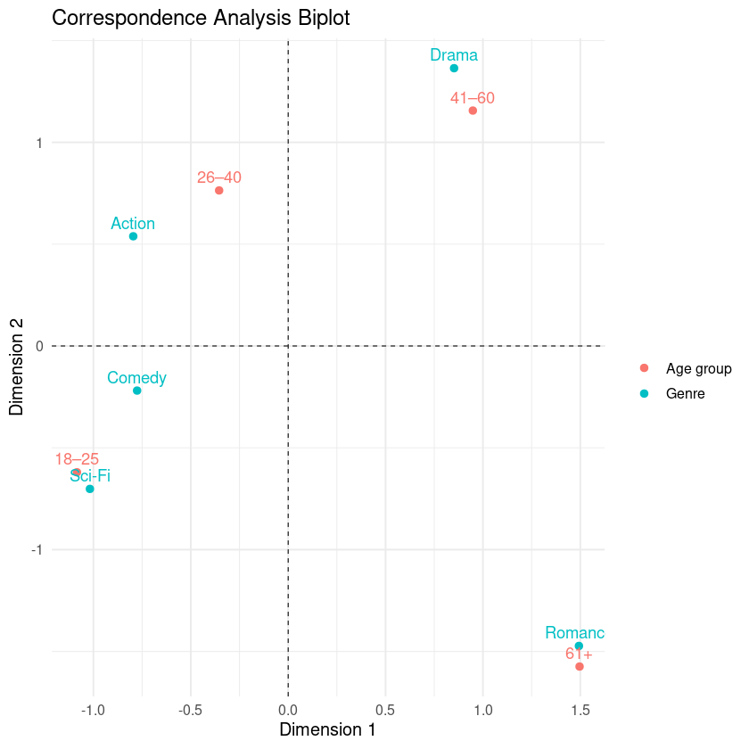

```r
# Base R CA plot (biplot of rows and columns)
plot(ca.fit,     main = "Correspondence Analysis: Age Group vs Movie Preference")

# Optional: Tidy coordinates for custom ggplot biplot
row_coords = as.data.frame(ca.fit$rowcoord)
row_coords$Label = rownames(row_coords)
row_coords$Type = "Age group"

col_coords = as.data.frame(ca.fit$colcoord)
col_coords$Label = rownames(col_coords)
col_coords$Type = "Genre"

coords = rbind(row_coords, col_coords)

ggplot(coords, aes(x = Dim1, y = Dim2, label = Label, color = Type)) +
  geom_hline(yintercept = 0, linewidth = 0.3, linetype = "dashed") +
  geom_vline(xintercept = 0, linewidth = 0.3, linetype = "dashed") +
  geom_point(size = 2) +
  geom_text(vjust = -0.6, show.legend = FALSE) +
  theme_minimal(base_size = 12) +
  labs(
    title = "Correspondence Analysis Biplot",
    x = "Dimension 1",
    y = "Dimension 2",
    color = ""
  )
```

In the correspondence analysis biplot, the rows (red points) represent the age groups, and the columns (blue points) represent the movie genres. The distances between points indicate how similar or different their preference profiles are. Points that lie close together share similar response patterns, suggesting similar movie taste distributions across age groups or genres, while points that are far apart indicate more distinct preferences. The axes Dimension 1 (horizontal) and Dimension 2 (vertical) summarize the main sources of variation in the data. Dimension 1 captures the strongest contrast between age–genre associations, while Dimension 2 explains a secondary and independent pattern of variation in viewing preferences.

```r
Example: Diamond data (https://jse.amstat.org/v9n2/4Cdata.txt)

Correspondence Analysis on Color and Clarity of diamonds.


  Columns
      1 -  4  Carat - Weight of diamond stones in carat units
      6       Colour - D, E, F, G, H or I
      8 - 11  Clarity - IF, VVS1, VVS2, VS1 or VS2
     13 - 15  Certification Body - GIA, IGI or HRD
     18 - 21  Price (Singapore $)
```

```r
dat = read.table("https://jse.amstat.org/v9n2/4Cdata.txt", header=0)

head(dat)
```

A data.frame: 6 × 5

|  | V1 <dbl> | V2 <chr> | V3 <chr> | V4 <chr> | V5 <int> |
| --- | --- | --- | --- | --- | --- |
| 1 | 0.30 | D | VS2 | GIA | 1302 |
| 2 | 0.30 | E | VS1 | GIA | 1510 |
| 3 | 0.30 | G | VVS1 | GIA | 1510 |
| 4 | 0.30 | G | VS1 | GIA | 1260 |
| 5 | 0.31 | D | VS1 | GIA | 1641 |
| 6 | 0.31 | E | VS1 | GIA | 1555 |

```r
#Constuct a two way table

TTab = table( dat$V2, dat$V3 )

TTab
```

```
    IF VS1 VS2 VVS1 VVS2
  D  1   7   2    2    4
  E  5  18   7    5    9
  F  8  25  14   18   17
  G 11  12   9   12   21
  H 11  11  14   10   15
  I  8   8   7    5   12
```

```r
ca.fit = ca(TTab)
summary(ca.fit)
```

```
Principal inertias (eigenvalues):

 dim    value      %   cum%   scree plot
 1      0.047531  69.7  69.7  *****************
 2      0.011899  17.4  87.1  ****
 3      0.008435  12.4  99.5  ***
 4      0.000347   0.5 100.0
        -------- -----
 Total: 0.068211 100.0


Rows:
    name   mass  qlt  inr    k=1 cor ctr    k=2 cor ctr
1 |    D |   52  926  141 | -395 843 171 | -123  82  67 |
2 |    E |  143  976  242 | -306 808 281 | -139 168 233 |
3 |    F |  266  998  174 | -150 503 126 |  149 495 494 |
4 |    G |  211  669  172 |  193 669 165 |   -3   0   0 |
5 |    H |  198  659  161 |  189 648 149 |   25  11  10 |
6 |    I |  130  996  110 |  199 686 109 | -134 310 196 |

Columns:
    name   mass  qlt  inr    k=1 cor ctr    k=2 cor ctr
1 |   IF |  143  963  190 |  279 858 234 |  -98 106 115 |
2 |  VS1 |  263 1000  461 | -341 973 643 |  -56  27  70 |
3 |  VS2 |  172  169   88 |   65 122  15 |   40  47  24 |
4 | VVS1 |  169  937  132 |   17   5   1 |  223 932 708 |
5 | VVS2 |  253  688  129 |  141 575 106 |  -62 113  83 |
```

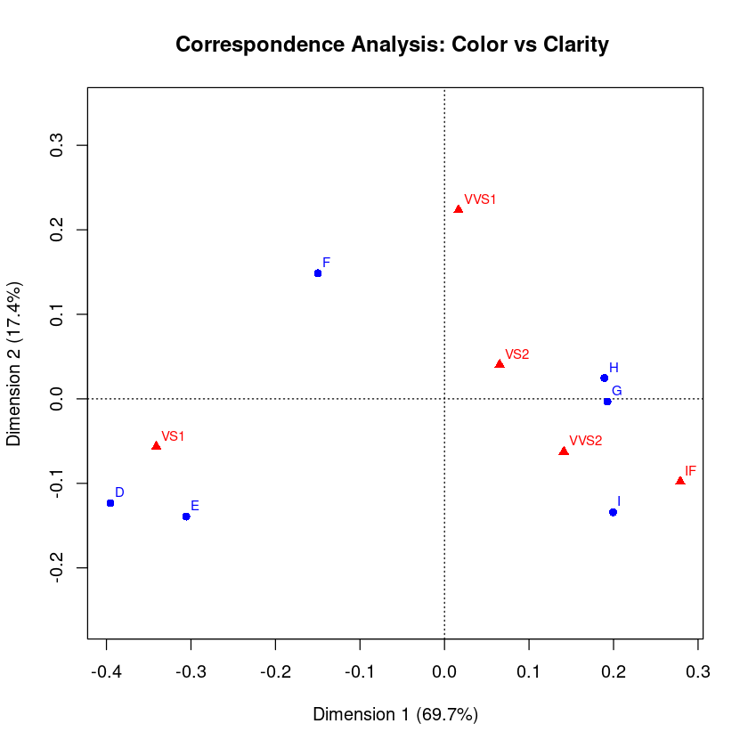

```r
# Base R CA plot (biplot of rows and columns)
plot(ca.fit,     main = "Correspondence Analysis: Color vs Clarity ")
```

# 🌐 Three-Way (Multiple) Correspondence Analysis (MCA)

When a dataset contains **more than two categorical variables**, a simple two-way Correspondence Analysis (CA) is no longer sufficient because it only handles one contingency table (rows × columns). To explore relationships among **three or more categorical variables**, we use **Multiple Correspondence Analysis (MCA)**, which generalizes CA to handle **multiway tables** or **categorical data frames**.

Typical Scenarios:

- The `HairEyeColor` dataset (Hair × Eye × Sex)
- Surveys with multiple categorical questions (e.g., Education × Income × Preference × Gender)
- Market research (Brand × Product × Age Group × Region)

MCA visualizes how the categories of **all variables** relate to each other and to the overall structure of the dataset.

Mathematical Idea (Simplified)

For a two-way table, CA decomposes: $$ S = D_r^{-1/2}(P - r c^T) D_c^{-1/2}. $$

For a **three-way table**, we first reshape it into a **binary indicator matrix**, where each row corresponds to an observation, and each column represents a category (1 = present, 0 = absent).

MCA then performs a **singular value decomposition (SVD)** on this indicator matrix to find **latent dimensions** that best represent the associations among all category levels.

Example Dataset: Hair × Eye × Sex

R’s built-in `HairEyeColor` dataset provides counts of 592 students classified by three categorical variables:

- **Hair color**: Black, Brown, Red, Blond
- **Eye color**: Brown, Blue, Hazel, Green
- **Sex**: Male, Female

We can analyze this as a **three-way contingency table** or convert it to a **two-dimensional data frame** suitable for MCA.